# 01-Figure 1 Main Results

```python
import pandas as pd
from pathlib import Path
import statsmodels.api as sm
from statsmodels.tools.tools import add_constant
import warnings
import numpy as np
from scipy.stats import sem
import matplotlib.pyplot as plt
```

#### Generalized Linear Models

Firing rate and phoneme data for GLM regression analysis are located in `Fig1-phoneme_regressions.xlsx`. Sheets in this file are labeled with the data they contain. Each column in sheets labeled "neural_data" represents the number of spikes observed from a single unit in the 500 ms prior to word onset, with each row representing a different word. The phonemic composition of each of these words is presented in sheets labeled "phoneme_data". These data only represent non-overlapping trials, i.e. ones in which words for which the planning periods did not overlap with the prior word's planning period. The firing rates are modeled as the realization of a Poisson process whose rate varied as a function of the phonemic word features. For comparison, null models are based on phoneme length only.

```python
file_name = Path().cwd() / 'Fig1-phoneme_regressions.xlsx'
data = pd.read_excel(file_name, sheet_name=None)
```

```python
# Example data
data['A_neural_data'].head(6)
```

|  | unit_63 | unit_64 | unit_65 | unit_66 | unit_67 | unit_68 | unit_69 | unit_70 | unit_71 | unit_72 | ... | unit_84 | unit_85 | unit_86 | unit_87 | unit_88 | unit_89 | unit_90 | unit_91 | unit_92 | unit_93 |
| --- | --- | --- | --- | --- | --- | --- | --- | --- | --- | --- | --- | --- | --- | --- | --- | --- | --- | --- | --- | --- | --- |
| 0 | 0 | 0 | 0 | 10 | 0 | 0 | 0 | 0 | 0 | 5 | ... | 5 | 0 | 0 | 0 | 0 | 0 | 1 | 4 | 0 | 0 |
| 1 | 0 | 0 | 0 | 9 | 0 | 0 | 0 | 0 | 4 | 0 | ... | 0 | 2 | 3 | 0 | 0 | 1 | 3 | 8 | 0 | 0 |
| 2 | 0 | 0 | 1 | 7 | 0 | 0 | 0 | 0 | 9 | 0 | ... | 1 | 2 | 3 | 0 | 0 | 5 | 4 | 1 | 2 | 0 |
| 3 | 0 | 0 | 6 | 7 | 0 | 0 | 0 | 0 | 4 | 1 | ... | 0 | 3 | 2 | 0 | 0 | 1 | 4 | 1 | 5 | 0 |
| 4 | 0 | 0 | 0 | 5 | 0 | 0 | 0 | 0 | 5 | 0 | ... | 1 | 4 | 0 | 0 | 0 | 3 | 17 | 4 | 0 | 0 |
| 5 | 0 | 0 | 0 | 8 | 0 | 0 | 0 | 0 | 4 | 0 | ... | 0 | 0 | 1 | 0 | 0 | 0 | 5 | 7 | 0 | 0 |

6 rows × 31 columns

```python
data['A_phoneme_data'].head(6)
```

|  | mid-low | alveolar | high | velar | bilabial | dental | labiodental | post-alveolar | glottal | palatal | total_phonemes |
| --- | --- | --- | --- | --- | --- | --- | --- | --- | --- | --- | --- |
| 0 | 1 | 0 | 0 | 0 | 1 | 0 | 0 | 0 | 0 | 1 | 3 |
| 1 | 1 | 1 | 0 | 1 | 0 | 0 | 0 | 0 | 0 | 0 | 3 |
| 2 | 0 | 1 | 1 | 0 | 0 | 0 | 0 | 0 | 0 | 0 | 2 |
| 3 | 1 | 0 | 0 | 0 | 0 | 0 | 0 | 0 | 0 | 0 | 1 |
| 4 | 1 | 1 | 0 | 1 | 0 | 0 | 0 | 0 | 0 | 0 | 3 |
| 5 | 1 | 0 | 1 | 1 | 1 | 0 | 0 | 0 | 0 | 0 | 4 |

```python
# Example model
subject = 'A'
unit_id = 66
spike_counts = data[subject+'_neural_data']['unit_'+str(unit_id)]
phonemes = data[subject+'_phoneme_data']
model = sm.GLM(endog=spike_counts, exog=add_constant(phonemes), family=sm.families.Poisson()).fit()
model.summary()
```

Generalized Linear Model Regression Results

| Dep. Variable: | unit_66 | No. Observations: | 184 |
| --- | --- | --- | --- |
| Model: | GLM | Df Residuals: | 173 |
| Model Family: | Poisson | Df Model: | 10 |
| Link Function: | Log | Scale: | 1.0000 |
| Method: | IRLS | Log-Likelihood: | -411.14 |
| Date: | Mon, 20 Nov 2023 | Deviance: | 501.07 |
| Time: | 16:27:21 | Pearson chi2: | 512. |
| No. Iterations: | 6 | Pseudo R-squ. (CS): | 0.2868 |
| Covariance Type: | nonrobust |  |  |

|  | coef | std err | z | P>\|z\| | [0.025 | 0.975] |
| --- | --- | --- | --- | --- | --- | --- |
| const | 0.0155 | 0.288 | 0.054 | 0.957 | -0.550 | 0.581 |
| mid-low | 1.0490 | 0.283 | 3.706 | 0.000 | 0.494 | 1.604 |
| alveolar | -0.3592 | 0.192 | -1.866 | 0.062 | -0.736 | 0.018 |
| high | 0.8170 | 0.306 | 2.672 | 0.008 | 0.218 | 1.416 |
| velar | 0.1568 | 0.184 | 0.850 | 0.395 | -0.205 | 0.518 |
| bilabial | -0.9025 | 0.215 | -4.206 | 0.000 | -1.323 | -0.482 |
| dental | -0.7470 | 0.184 | -4.070 | 0.000 | -1.107 | -0.387 |
| labiodental | -0.2389 | 0.310 | -0.771 | 0.441 | -0.847 | 0.369 |
| post-alveolar | 0.6524 | 0.358 | 1.824 | 0.068 | -0.048 | 1.353 |
| glottal | -3.163e-15 | 1.06e-15 | -2.976 | 0.003 | -5.25e-15 | -1.08e-15 |
| palatal | 0.7643 | 0.353 | 2.165 | 0.030 | 0.072 | 1.456 |
| total_phonemes | 0.0581 | 0.113 | 0.514 | 0.608 | -0.164 | 0.280 |

#### Selectivity Curves

The signs of model coefficients indicate the phonemic composition that would be expected to elicit the maximum firing rate for each neuron. File `Fig1-phoneme_selectivity.xlsx` contains the Z-scored firing rate preceding each word for neurons exhibiting statistically significant overall phoneme model fit, along with the Hamming distance of each word's phoneme vector from the neuron's "ideal" word according to the GLM.

```python
# Load data

file_name = Path().cwd() / 'Fig1-phoneme_selectivity.xlsx'
data = pd.read_excel(file_name)
```

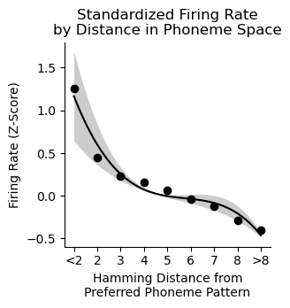

```python
# Plot average firing rate z-score as a function of hamming distance from "preferred word"

unique_distances = data['hamming_dist'].unique().tolist()
unique_distances.sort()

neuron_avgs = []
with warnings.catch_warnings():
    warnings.simplefilter("ignore", category=RuntimeWarning)
    for neuron in data['unit_index'].unique():
        neuron_avgs.append([])
        _data = data.loc[data['unit_index']==neuron]
        for d in unique_distances[1:-1]:
            if d==unique_distances[1]:
                neuron_avgs[-1].append(np.mean(_data.loc[_data['hamming_dist']==d]['fr_zscore']))
            elif d==unique_distances[-1]:
                neuron_avgs[-1].append(np.mean(_data.loc[_data['hamming_dist']==d]['fr_zscore']))
            else:
                neuron_avgs[-1].append(np.mean(_data.loc[_data['hamming_dist']==d]['fr_zscore']))
neuron_avgs = np.array(neuron_avgs)

x = range(len(unique_distances)-2)
y = np.nanmean(neuron_avgs, axis=0)
y_sem = sem(neuron_avgs, nan_policy='omit').data

z = np.polyfit(x, y, deg=3)
p = np.poly1d(z)
z = np.polyfit(x, y_sem, deg=3)
s = np.poly1d(z)

fig, ax = plt.subplots(figsize=(3,3))
ax.set_title('Standardized Firing Rate\nby Distance in Phoneme Space')
ax.set_ylabel('Firing Rate (Z-Score)')
ax.set_xlabel('Hamming Distance from\nPreferred Phoneme Pattern')
ax.scatter(x, np.nanmean(neuron_avgs, axis=0), c='k')

x_new = np.linspace(min(x), max(x), 100)
ax.plot(x_new, p(x_new), c='k')
ax.fill_between(x_new, p(x_new)+s(x_new), p(x_new)-s(x_new), color='k', lw=0., alpha=0.2);
ax.set_xticks(np.arange(9), labels=['<2','2','3','4','5','6','7','8','>8']);
ax.spines['top'].set_visible(False)
ax.spines['right'].set_visible(False)
```

#### Decoding Phonemes

Decoders were trained using data from all words (regardless of overlap) and all neurons. For each phoneme type, trials were matched according to the presence or absence of the phoneme being decoded, in trial sequential order without duplicating or upsampling trials. Z-scored neuronal firing rates during the planning period were used to train SVM decoders to use neuronal data to predict the presence or absence of specific phonemes in upcoming words. Data used to construct decoders is located in `Fig1-phoneme_decoding.xlsx`. Data for each phoneme type is stored in separate sheets in the spreadsheet.

```python
file_name = Path().cwd() / 'Fig1-phoneme_decoding.xlsx'
data = pd.read_excel(file_name, sheet_name=None)
```

```python
# Example data
data['glottal'].head()
```

|  | target | unit_0 | unit_1 | unit_2 | unit_3 | unit_4 | unit_5 | unit_6 | unit_7 | unit_8 | ... | unit_262 | unit_263 | unit_264 | unit_265 | unit_266 | unit_267 | unit_268 | unit_269 | unit_270 | unit_271 |
| --- | --- | --- | --- | --- | --- | --- | --- | --- | --- | --- | --- | --- | --- | --- | --- | --- | --- | --- | --- | --- | --- |
| 0 | 0 | 0.737478 | -0.466416 | -0.148333 | -0.289555 | -0.028752 | -0.563658 | -0.644027 | -0.283556 | -0.453660 | ... | -0.267877 | -0.756558 | -0.690086 | 0.419753 | -0.198426 | 1.520460 | -0.67702 | -0.590126 | -0.776143 | -0.743197 |
| 1 | 0 | 0.737478 | -0.466416 | -0.577743 | -0.289555 | -0.894911 | -0.563658 | -0.644027 | -0.283556 | 1.360979 | ... | -0.267877 | -0.756558 | -0.690086 | -0.129680 | -0.601113 | 1.520460 | -0.67702 | -0.590126 | -0.776143 | -0.743197 |
| 2 | 0 | 0.737478 | -0.466416 | -0.577743 | -0.289555 | -0.894911 | -0.563658 | -0.299306 | -0.283556 | 1.360979 | ... | -0.267877 | 0.405712 | -0.690086 | 0.419753 | -0.601113 | -0.214848 | -0.67702 | -0.590126 | -0.776143 | -0.743197 |
| 3 | 0 | 0.737478 | -0.466416 | -0.577743 | -0.289555 | -0.028752 | -0.563658 | -0.299306 | -0.283556 | 1.360979 | ... | -0.267877 | 0.986846 | -0.690086 | 0.694469 | -0.601113 | -0.214848 | -0.67702 | -0.378804 | -0.776143 | -0.743197 |
| 4 | 0 | 0.737478 | -0.466416 | -0.577743 | -0.289555 | -0.028752 | -0.563658 | -0.644027 | -0.283556 | -0.453660 | ... | -0.267877 | -0.756558 | -0.690086 | 0.419753 | -0.601113 | -0.214848 | -0.67702 | -0.590126 | -0.776143 | -0.743197 |

5 rows × 273 columns

```python
# Decoders

from sklearn.model_selection import cross_val_score, GridSearchCV, StratifiedKFold, StratifiedShuffleSplit
from sklearn.svm import SVC

inner_cv = StratifiedKFold(n_splits=2, shuffle=True, random_state=1)
outer_cv = StratifiedShuffleSplit(n_splits=50, test_size=0.25, random_state=1)
svc = SVC(class_weight='balanced', kernel='rbf', gamma='auto', random_state=3)
parameters = {"C":[1e-6, 1e-5, 1e-4, 1e-3, 1e-2, 1e-1, 1]}
grid = GridSearchCV(estimator=svc, param_grid=parameters, scoring='roc_auc', cv=inner_cv, n_jobs=4)

scores = {}

for feature in data.keys():
    X = data[feature].values[:,1:]
    y = data[feature].values[:,0].astype(int)
    scores[feature] = cross_val_score(grid, X, y, scoring='roc_auc', cv=outer_cv, n_jobs=2)
```

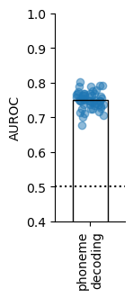

```python
fig, ax = plt.subplots(figsize=(1,3))
rng = np.random.default_rng()
ax.scatter(x=rng.random(50)*0.4+0.3, y=np.array([*scores.values()]).mean(axis=0), alpha=0.5)
ax.bar(x=0.5, height=np.array([*scores.values()]).mean(axis=(0,1)), facecolor='none', edgecolor='black', width=0.5)
ax.axhline(0.5, ls=':', c='k')
ax.set_xlim(0,1)
ax.set_ylim(0.4, 1.0)
ax.set_xticks([0.5], labels=['phoneme\ndecoding'], rotation=90)
ax.set_ylabel('AUROC')
ax.spines['top'].set_visible(False)
ax.spines['right'].set_visible(False)
```